# Brazilian E-Commerce | Sales & Customer Insights

Análise de vendas, logística e experiência do cliente usando R

Autor

Thiago Andrade

## Contexto de negocio

Este estudo investiga o desempenho de pedidos de e-commerce no Brasil, com enfoque em **vendas de produtos, distribuicao geografica, cumprimento de prazos e satisfacao**. A fonte e a base publica Olist, com observacoes historicas de 2016 a 2018. O escopo da analise inclui **pedidos entregues que possuem itens cadastrados**.

## Indicadores principais

- **Pedidos analisados:** 96.478
- **GMV de produtos (sem frete):** R$ 13.221.498,11
- **Ticket medio por pedido:** R$ 137,04
- **Entregas no prazo (com data conhecida):** 93,2%
- **Nota media dos pedidos avaliados:** 4,16 / 5
- **Clientes com dois ou mais pedidos entregues:** 3,0%

> **Cuidado de metrica:** “GMV” aqui e a soma de `price` dos itens, sem frete. Não é receita líquida nem comissão da plataforma. A taxa de recorrencia representa apenas as compras observadas no período da amostra.

## Evolucao comercial

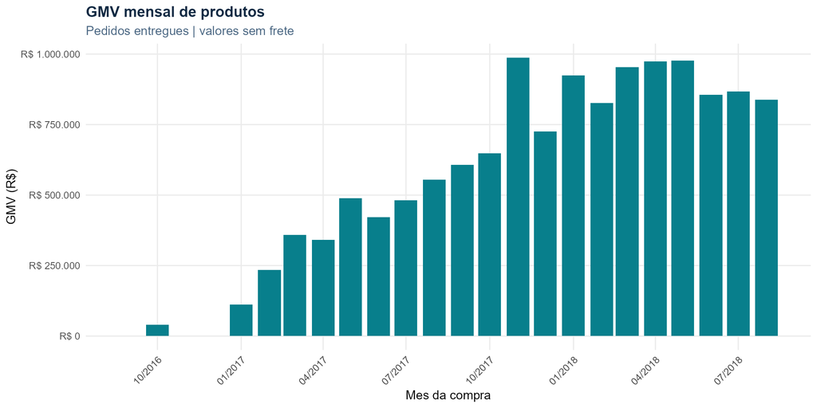

GMV mensal dos pedidos entregues, agrupado pela data de compra.

A interpretacao deve considerar que o periodo de observacao e historico, possui janelas possivelmente incompletas e nao permite inferir crescimento posterior a 2018.

## Desempenho geografico

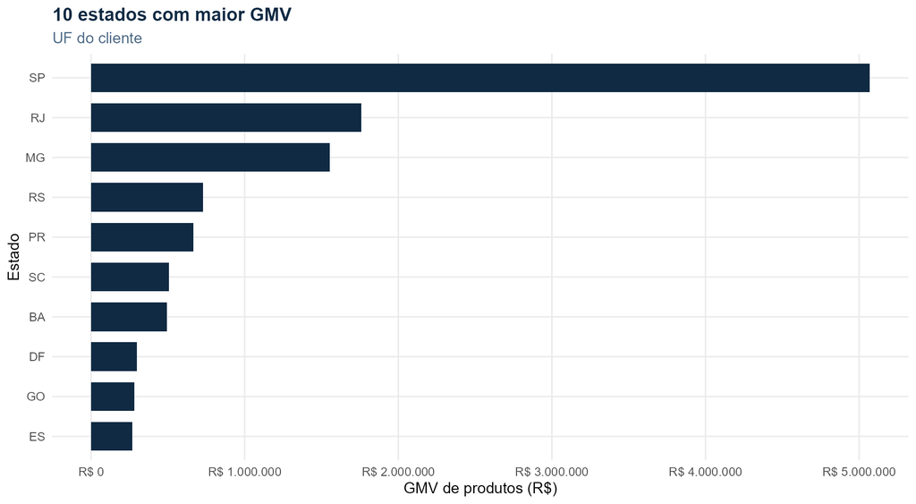

Estados dos clientes com maior GMV de produtos.

O campo geografico corresponde ao **estado do cliente**, nao a localizacao do vendedor ou da entrega em rota.

## Entrega e satisfacao

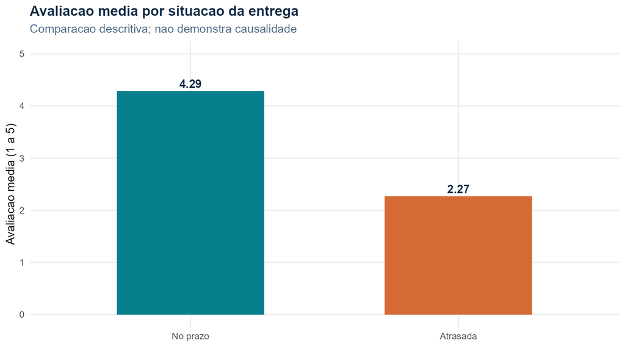

Avaliacao média dos pedidos com entrega no prazo vs. atrasada.

Indicadores de satisfacão por status de entrega

| Situacão | Pedidos avaliados | Nota média | Notas 1-2 |
| --- | --- | --- | --- |
| Atrasada | 6381 | 2.27 | 62,4% |
| No prazo | 89443 | 4.29 | 9,3% |

A diferenca entre os grupos e uma **associacao descritiva**, nao uma prova de que o atraso causou a nota. Outros fatores nao observados podem influenciar a satisfacao.

## Recorrencia de compra

A base inclui **93.358 clientes unicos com pedido entregue**; destes, **2.801** aparecem com dois ou mais pedidos entregues. Esta medida nao e uma taxa de retencao por coorte, pois os clientes tiveram diferentes periodos de observacao.

## Qualidade dos dados

Controle de qualidade e critérios de exclusão

|  | Metrica | Quantidade |
| --- | --- | --- |
| pedidos_entregues_na_origem | Pedidos entregues na fonte | 96478 |
| pedidos_entregues_sem_itens | Sem itens | 0 |
| pedidos_na_base_final | Pedidos modelados | 96478 |
| pedidos_sem_data_compra | Sem data de compra | 0 |
| pedidos_sem_info_prazo | Sem informação de prazo | 8 |
| pedidos_sem_avaliacao | Sem avaliação | 646 |
| pedidos_com_valor_nao_positivo | Valor de produtos não positivo | 0 |

## Recomendacoes a investigar

1. **Operacao:** identificar regioes e periodos com maior percentual de entregas atrasadas antes de redesenhar processos logisticos.
2. **Experiencia do cliente:** priorizar diagnosticos de pedidos atrasados com notas baixas; investigar causas adicionais antes de inferir causalidade.
3. **Comercial:** analisar segmentos com maior valor de pedidos e comparar o potencial de recompra por coortes de aquisicao, como extensao futura.

Essas sao **hipoteses e linhas de acao para investigacao**, nao conclusoes confirmadas sobre fatores causais.

## Fonte, metodologia e limitacoes

Fonte: [Brazilian E-Commerce Public Dataset by Olist (Kaggle)](https://www.kaggle.com/datasets/olistbr/brazilian-ecommerce).

Os scripts agregam itens por pedido antes da integracao, selecionam uma avaliacao por pedido e preservam uma linha por pedido. Atraso e definido pela **data de entrega posterior ao dia estimado**; entregas com datas ausentes nao entram no denominador da pontualidade. O recorte abrange apenas pedidos entregues com itens, e os resultados nao representam pedidos cancelados, faturamento liquido nem a situacao atual do comercio eletronico brasileiro.

Codigo e reproducao: consulte o arquivo `README.md` no repositorio deste projeto.